# The Chi-squared distribution and related tests

Denis Puthier

2018-10-08

# The $\chi^2$ distribution

## Definition

**from wikipedia**: In probability theory and statistics, the chi-squared distribution (also chi-square or $\chi^2$-distribution) with k degrees of freedom is the distribution of a sum of the squares of k independent standard normal random variables.

In other words, given $x_1, x_2, ... , x_i$, $k$ independent variables drawn from a normal distribution with mean 0 and standard deviation1, then the sum of their squares:

$$Q\ = \sum_{i=1}^k x_i^2$$

is distributed according to the chi-squared distribution with $k$ degrees of freedom. It is generally denoted as
$$Q\ \sim\ \chi^2(k)\ \ \text{or}\ \ Q\ \sim\ \chi^2_k .$$

## Probability density function of $\chi^2$ distribution

The probability density function (pdf) of the chi-square distribution is:

$$f(x;\,k) =
\begin{cases}
\dfrac{x^{\frac k 2 -1} e^{-\frac x 2}}{2^{\frac k 2} \Gamma\left(\frac k 2 \right)}, & x > 0; \\ 0, & \text{otherwise}.
\end{cases}$$

- Check, using a diagram and using standard R functions/operators that, for $k_val=5$ the mathematical formula fits with the values returns by *dchisq()* function.

<< Hide | Show >>

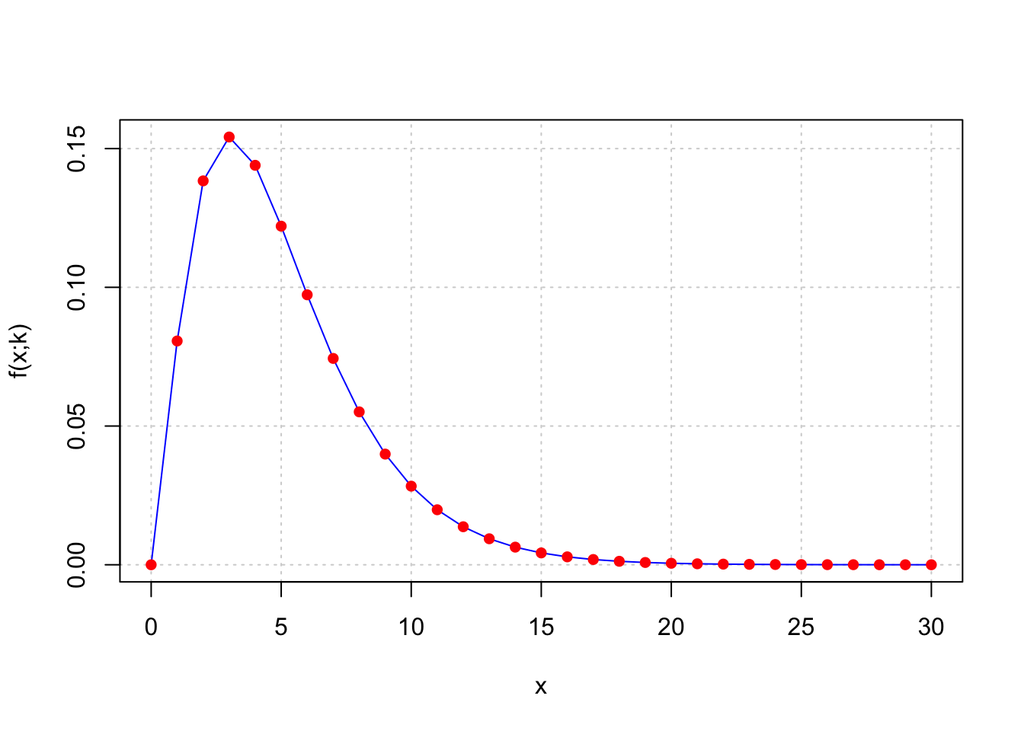

```r
k_val <- 5
x <- 0:30
denom = (2^(k_val/2)*gamma(k_val/2))
num = x^(k_val/2-1)*exp(-x/2)

plot(0:30, num/denom,
     type="l",
     col="blue",
     panel.first = grid(),
     xlab="x",
     ylab="f(x;k)")
points(0:30,
       dchisq(0:30, df=k_val),
       col="red",
       lw=2,
       pch=16)
```

## Testing the model

In the exercice below will compare the $\chi^2$ distribution model to a distribution obtained by randomly computing values for $Q$ with a fixed degree of freedom.

**NB**: Regarding R code, we will use “_" characters for naming variables instead of classical ‘.’. This refers to the official [Hadley style of coding](http://stat405.had.co.nz/r-style.html). This is more Pythonic !!

- create a variable $k\_val$ that will be set to 5.
- Using the *replicate()* function and the *rnorm()* function, create 100000 samples of size $k\_val$ taken from a normal distribution with population mean 0 and standard deviation 1.
- Using *colSums()*, compute, for each sample, the sum of the squares.
- Draw the distribution of the obtained dataset.
  - Using the *hist()* function.
  - Using the *density()* and *plot()* function.
- Using the *dchisq()* function, check that the obtained distribution is well modeled by the $\chi^2$ distribution.
- Compute the $\chi^2$ distribution using $k\_val$ ranging from 5 to 50 with step by 5.
- Conclude.

<< Hide | Show >>

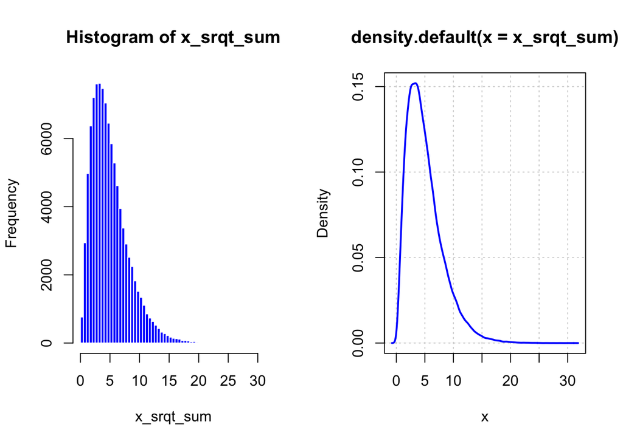

```r
#-----------------------------------------------------------------------
# Using the replicate() function and the rnorm() function, create 100000
# samples of size k_val taken from a
# normal distribution with population mean 0 and standard deviation 1
#-----------------------------------------------------------------------
n <- 100000
x_val <- replicate(n, rnorm(5, mean = 0, sd = 1))

#-----------------------------------------------------------------------
# Using *colSums()*, compute, for each sample, the sum of the squares.
#-----------------------------------------------------------------------
x_srqt_sum <- colSums(x_val^2)
par(mfrow=c(1,2))

#-----------------------------------------------------------------------
# Draw the distribution of the obtained dataset.
#-----------------------------------------------------------------------

hist(x_srqt_sum,
     col="blue",
     border = "white",
     breaks = 100)
plot(density(x_srqt_sum),
     lwd=2,
     col="blue",
     panel.first=grid(),
     xlab="x")
```

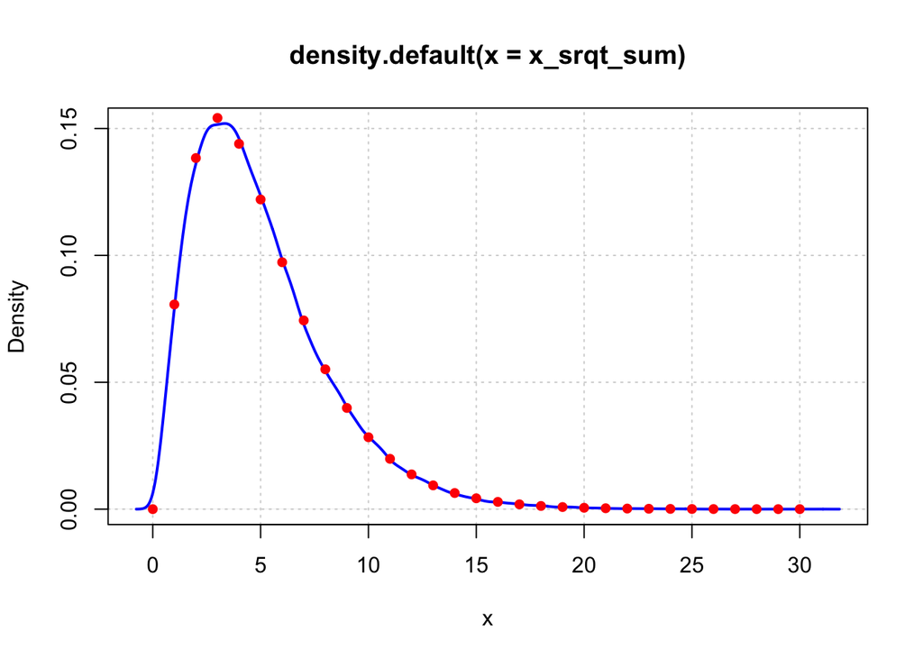

```r
#-----------------------------------------------------------------------
# Using the *dchisq* function, check that the obtained distribution is
# well modeled by the $\chi^2$ distribution.
#-----------------------------------------------------------------------
par(mfrow=c(1,1))
plot(density(x_srqt_sum),
     lwd=2,
     col="blue",
     panel.first=grid(),
     xlab="x")
points(0:30,
       dchisq(0:30, df=k_val),
       col="red",
       lw=2,
       pch=16)
```

## Computing the $\chi^2$ distribution for various degree of freedom

- Compute the $\chi^2$ distribution for various degree of freedom (1,5,15…50).

<< Hide | Show >>

```r
## Create a color palette
if(!require(RColorBrewer)) install.packages('RColorBrewer')
```

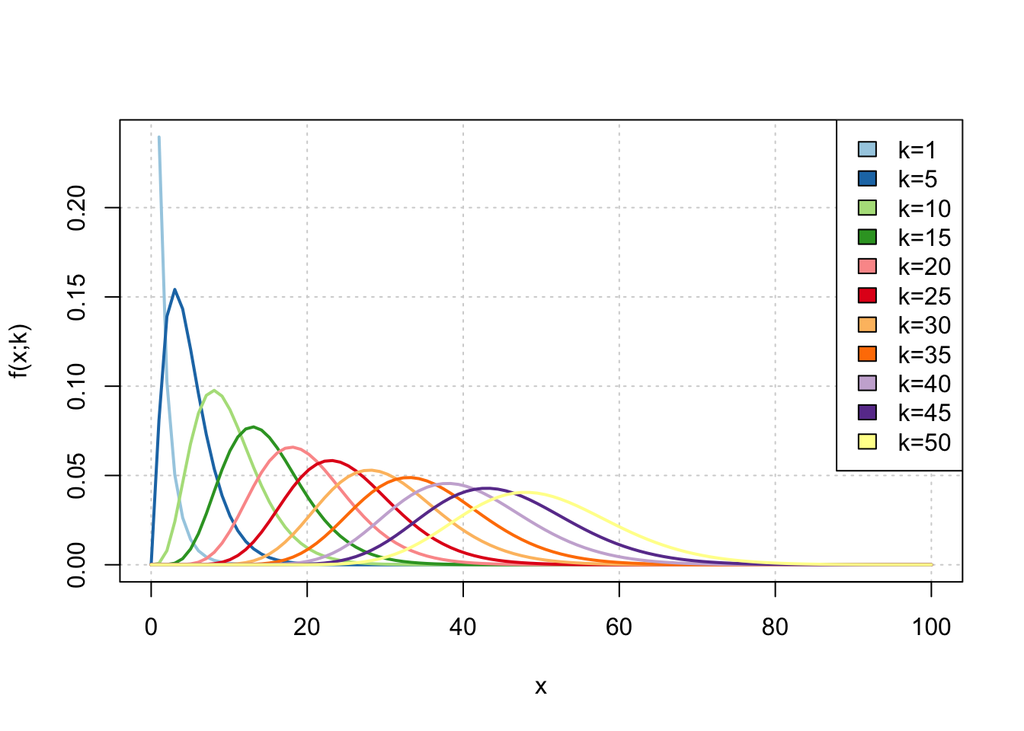

```r
color_pal <- brewer.pal(11, name = "Paired")


## Compute and draw density diagram of Chi-squared Distribution
# The values taken by k will be successively 1,5,15...50
k_val <- c(1, seq(5, 50, by=5))

# Draw a Chi-squared Distribution for k = 1
xlim <- c(0,100)
i = 1
plot(seq(xlim[1], xlim[2], length.out = 100),
     dchisq(k_val[i], x=seq(xlim[1], xlim[2], length.out = 100)),
     type="l", col= color_pal[i],
     panel.first = grid(),
     lwd=2,
     xlab="x",
     ylab="f(x;k)"
     )

for(i in 2:length(k_val)){
  points(seq(xlim[1], xlim[2], length.out = 100),
         dchisq(k_val[i], x=seq(xlim[1], xlim[2], length.out = 100)),
         type="l",
         col= color_pal[i],
         lwd=2)
}

legend("topright",
       legend=paste("k=", k_val, sep=""),
       fill=color_pal)
```

# Chi-squared test

In statistics, a $\chi^2$ test, is a statistical test in which the sampling distribution of the test statistic follows a $\chi^2$ distribution under the null hypothesis. The $\chi^2$ statistics is used in several statistical tests. However, without other qualification, ‘chi-squared test’ is often used as short for Pearson’s chi-squared test. The chi-squared test is used to determine whether there is a significant difference between the expected frequencies and the observed frequencies in one or more categories.

## Pearson’s chi-squared test

Suppose that n observations in a random sample from a population are classified into k mutually exclusive classes with respective observed numbers $x_i$ (for $i=1,2...k$),and a null hypothesis gives the probability $p_i$ that an observation falls into the ith class. So we have the expected numbers $m_i = np_i$ for all $i$, where:

$$\sum^k_{i=1}{p_i} = 1$$
$$\sum^k_{i=1}{m_i} =n\sum^k_{i=1}{p_i} = \sum_{i=1}^{k}x_i$$

Pearson proposed that, under the circumstance of the null hypothesis being correct, the score below follows $\chi^2$ distribution with $k-1$ degrees of freedom.

$$X^2=\sum^k_{i=1}{\frac{(x_i-m_i)^2}{m_i}}$$

This score is frequently viewed as:

$$X^2=\sum^k_{i=1}{\frac{(observed_i-expected_i)^2}{expected_i}}$$

### Using chi-squared to test for goodness of fit

The Pearson’s chi-squared test is frequently used to test whether a random variable $Y$ has a distribution that is compatible (*i.e* can be well modeled) with a known probability distribution (*e.g* normal, geometric, binomial…). It is thus a measure of, the goodness of fit, that is, how well the model fits the variable $Y$. When testing for goodness of fit using a $chi^2$ test, the null hypothesis is thus “$Y$ follows a distribution P”.

#### Example: checking the balance of a gaming dice

A gambler plays a game that involves throwing a dice in a succession of 100 trials. If the die being used is fair, then the chance of any particular number coming up is the same: 1/6. However, if the gambler uses a loaded diethen certain numbers will have a greater likelihood of appearing, while others will have a lower likelihood. The fairness of the dice can be tested using a $\chi^2$ test.

Let’s consider a random variable $Y$ that corresponds to the results obtained after throwing a dice 100 times:

```r
y <- c(11, 15, 16, 17, 18, 23)
names(y) <- 1:6
```

- Create a vector containing the probability associated with each face of a fair dice.
- Create a vector containing the expected number of success for each face with a fair dice.
- Compute the $\chi^2$ statistics.
- Compute the p-value for the associated $\chi^2$ statistics (the degree of freedom is $k-1$).
- Check that the same p-value is obtained using *chisq.test()*.
- Conclusion ?

<< Hide | Show >>

```r
## Create a vector containing the probability associated with each face of a fair dice.
prob <- rep(1/6, 6)

## Create a vector containing the probability associated with each face of a fair dice.
expected <- prob * 100

## Compute the $\chi^2$ statistics
chi_stat <- sum((y - expected)^2/expected)

## Compute the p-value for the associated $\chi^2$ statistics
pchisq(q=chi_stat, df=length(y)-1, lower.tail = FALSE)
```

```
## [1] 0.4613731
```

```r
## Check that the same p-value is obtained using chisq.test()
chi_test_res <- chisq.test(x=y, p=prob)
print(chi_test_res)
```

```
##
##  Chi-squared test for given probabilities
##
## data:  y
## X-squared = 4.64, df = 5, p-value = 0.4614
```

```r
is(chi_test_res)
```

```
## [1] "htest"
```

```r
names(chi_test_res)
```

```
## [1] "statistic" "parameter" "p.value"   "method"    "data.name" "observed"
## [7] "expected"  "residuals" "stdres"
```

```r
chi_test_res$p.value
```

```
## [1] 0.4613731
```

```r
## Conclude
# The observed sample frequencies do not differ significantly
# from the expected frequencies of fair dice.
```

#### Example: testing for a Poisson distribution.

Let’s consider a random variable $Y$ with null or positive discrete values. A sample of 100 values taken from$Y$ is provided below.

```r
y <- c(30, 43, 17, 8, 2)
names(y) <- c("0", "1", "2", "3", "4")
```

- Base on the provided sample, compute the expected mean ($\mu$) of the modeled Poisson distribution ($\mu=\sum_{i}^nx_ip_i$).
- What is the probability of observing $0,1...4,>4$ under a Poisson model with $\lambda=\mu$. Use de *dpois()* function ?
- What is the expected number of observation in each class under the same Poisson model ?
- Compute the $\chi^2$ statistics (for the vector Y the number of observation greater than 4 is 0 !).
- Compute the p-value for the associated $\chi^2$ statistics.
- Conclude.

<< Hide | Show >>

```r
## Compute the expected mean of the modeled Poisson distribution
mu <- sum(0:4*y/100)

## What is the probability of observing 0,1...4,>4 under a Poisson model with lambda=mu
prob <- c(dpois(0:4, lambda = mu), 1-sum(dpois(0:4, lambda = mu)))
# or
prob <- c(dpois(0:4, lambda = mu), ppois(q=4, lambda = mu, lower.tail = FALSE))

## What is the expected number of observation in each class under the same Poisson model ?

expected <- prob*100

## Compute the chi-squared statistics.

chi_stat <- sum((c(y,0)-expected)^2/expected)

## Compute the p-value for the associated chi-squared statistics.
pchisq(q=chi_stat, df=length(c(y,0))-2, lower.tail = FALSE)
```

```
## [1] 0.6386303
```

```r
## Conclude
# The observed sample frequencies do not differ significantly
# from the expected frequencies of a Poisson model with lambda = mu
```